# RQ2 Analyses — Variability, Correspondence, and H1c/d (AI Surrogates)

Bootstrap CIs · BCa sensitivity · Spearman · Polychoric · Steiger · Meta-r

Author

Caroline Müller

Published

May 16, 2026

# 1 Overview

**Prerequisite:** Run `10_RQ2_data.qmd` first to generate the required RDS exports in `10_data/80_analyses_exports/`.

This file covers all inferential RQ2 analyses:

- **RQ2a** Between-surrogate variability (SD) across 9 conditions
- **RQ2b** LLM–questionnaire correspondence (Pearson r) + Spearman + Polychoric robustness
- **BCa sensitivity** checks for SD and r (bounded/skewed distributions)
- **H1c** Discriminant validity — Steiger’s test, AI surrogates, all 9 conditions
- **H1d** Structural consistency — meta-r, AI surrogates, all 9 conditions

**Primary CIs:** Bootstrap percentile, R = 10,000. **Sensitivity CIs:** BCa (bias-corrected accelerated); divergence threshold = 0.02.

# 2 Setup

## 2.1 Environment

## 2.2 Shared Constants

## 2.3 Load Upstream Exports

## 2.4 Pivot to Wide Format for RQ2

# 3 RQ2a — Between-Surrogate Variability (SD)

RQ2a asks: to what extent do text length and number of texts affect between-surrogate variability (SD) in LLM scores?

## 3.1 Bootstrap SD

Resampling unit: personas. SD computed per condition × need on each bootstrap resample. 10,000 iterations, set.seed(2026).

## 3.2 BCa Sensitivity Check — SD

## 3.3 SD Results Table

Table 1: Bootstrap SD of LLM Scores by Condition and Need Dimension (RQ2a). Percentile CIs; R = 10,000.

| Need | Word length | 1 text | 3 texts | 5 texts |
| --- | --- | --- | --- | --- |
| Autonomy | short | 0.47 [0.44, 0.50] |  |  |
| Autonomy | short |  | 0.40 [0.35, 0.44] |  |
| Autonomy | short |  |  | 0.41 [0.36, 0.44] |
| Autonomy | medium | 0.39 [0.35, 0.43] |  |  |
| Autonomy | medium |  | 0.43 [0.40, 0.46] |  |
| Autonomy | medium |  |  | 0.45 [0.41, 0.49] |
| Autonomy | long | 0.43 [0.41, 0.46] |  |  |
| Autonomy | long |  | 0.46 [0.43, 0.48] |  |
| Autonomy | long |  |  | 0.46 [0.43, 0.49] |
| Competence | short | 0.43 [0.41, 0.45] |  |  |
| Competence | short |  | 0.47 [0.45, 0.48] |  |
| Competence | short |  |  | 0.47 [0.45, 0.48] |
| Competence | medium | 0.44 [0.42, 0.46] |  |  |
| Competence | medium |  | 0.37 [0.34, 0.40] |  |
| Competence | medium |  |  | 0.35 [0.31, 0.38] |
| Competence | long | 0.37 [0.33, 0.41] |  |  |
| Competence | long |  | 0.36 [0.32, 0.40] |  |
| Competence | long |  |  | 0.33 [0.28, 0.37] |
| Relatedness | short | 0.28 [0.23, 0.32] |  |  |
| Relatedness | short |  | 0.40 [0.36, 0.44] |  |
| Relatedness | short |  |  | 0.41 [0.38, 0.44] |
| Relatedness | medium | 0.40 [0.37, 0.42] |  |  |
| Relatedness | medium |  | 0.45 [0.43, 0.47] |  |
| Relatedness | medium |  |  | 0.46 [0.45, 0.47] |
| Relatedness | long | 0.46 [0.45, 0.47] |  |  |
| Relatedness | long |  | 0.46 [0.45, 0.47] |  |
| Relatedness | long |  |  | 0.46 [0.45, 0.47] |

Note. N = 394 AI surrogates. SD = between-surrogate SD per condition. Bootstrap percentile CIs, R = 10000, seed = 2026. BCa sensitivity check: see check_bca_divergence_sd.

## 3.4 SD Line Plot

Figure 1: Between-Surrogate SD of LLM Scores by Condition (RQ2a). Lines = number of texts; error bars = 95% percentile bootstrap CIs.

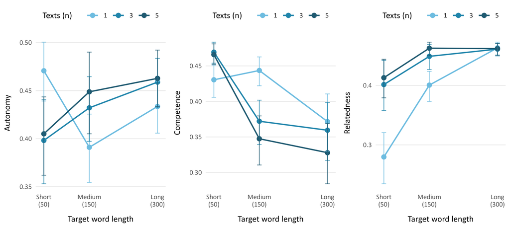

Figure 2: Between-surrogate SD of surrogate-level mean LLM scores by condition (RQ2a). Lines = number of texts (1, 3, 5); x-axis = target word length (fully independent). Error bars = 95% bootstrap CIs.

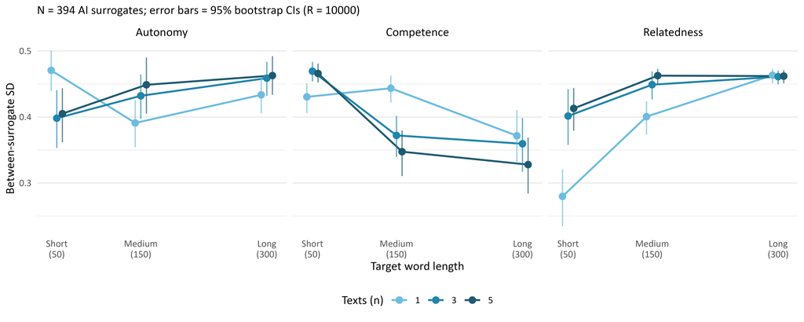

Figure 3: Between-surrogate SD of surrogate-level mean LLM scores by condition (RQ2a). Lines = number of texts (1, 3, 5), shaded light to dark; x-axis = target word length (fully independent). Error bars = 95% bootstrap CIs.

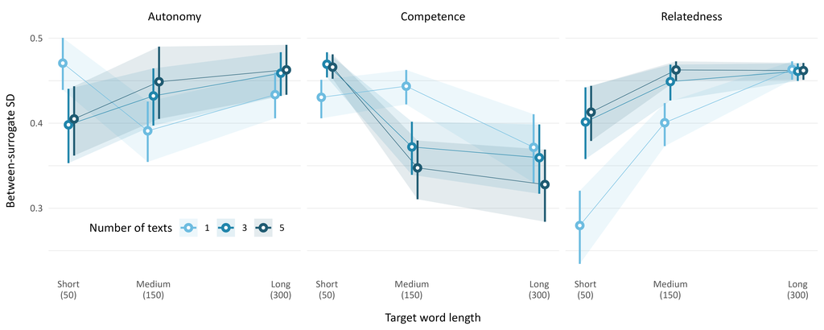

*Note.* N = 394 AI surrogates. Error bars = 95% bootstrap CIs (R = 10000). Line shading light to dark = 1, 3, 5 texts.

## 3.5 Pre-Specified Contrasts — SD

Table 2: Pre-Specified Contrasts for Between-Surrogate SD (RQ2a). Bootstrap percentile CIs; R = 10,000.

| Contrast | Delta SD (Aut) | Delta SD (Com) | Delta SD (Rel) |
| --- | --- | --- | --- |
| Length (long-short) \| 1 text | -0.04 [-0.08, 0.00] | -0.06 [-0.10, -0.01] | 0.18 [0.14, 0.23] |
| Length (long-short) \| 3 texts | 0.06 [0.01, 0.11] | -0.11 [-0.15, -0.07] | 0.06 [0.02, 0.10] |
| Length (long-short) \| 5 texts | 0.06 [0.01, 0.11] | -0.14 [-0.18, -0.10] | 0.05 [0.01, 0.08] |
| Texts (5-1) \| short | -0.07 [-0.11, -0.02] | 0.04 [0.01, 0.06] | 0.13 [0.08, 0.19] |
| Texts (5-1) \| medium | 0.06 [0.01, 0.11] | -0.10 [-0.13, -0.06] | 0.06 [0.04, 0.09] |
| Texts (5-1) \| long | 0.03 [-0.01, 0.06] | -0.04 [-0.09, 0.00] | -0.00 [-0.02, 0.01] |
| Grand diagonal (long-5 - short-1) | -0.01 [-0.05, 0.03] | -0.10 [-0.15, -0.06] | 0.18 [0.14, 0.23] |

Note. Bootstrap percentile CIs, R = 10000. Delta SD = condition A minus condition B.

# 4 RQ2b — LLM–Questionnaire Correspondence (Pearson r)

RQ2b asks: to what extent do text length and number of texts affect the LLM–questionnaire correlation?

## 4.1 Assumption Check — Linearity

LOESS vs OLS overlay for all 27 condition × need combinations.

Figure 4: Linearity Assumption: LOESS (solid) vs OLS (dashed) for each condition × need panel. Close agreement supports Pearson r.

[figure not shown]

## 4.2 Bootstrap Pearson r

## 4.3 BCa Sensitivity Check — Pearson r

## 4.4 Pearson r Results Table

Table 3: LLM–Questionnaire Pearson Correlations by Condition and Need Dimension (RQ2b). Percentile CIs; R = 10,000.

| Need | Word length | 1 text | 3 texts | 5 texts |
| --- | --- | --- | --- | --- |
| Autonomy | short | -0.04 [-0.13, 0.05] |  |  |
| Autonomy | short |  | 0.07 [-0.03, 0.17] |  |
| Autonomy | short |  |  | 0.09 [-0.02, 0.21] |
| Autonomy | medium | 0.13 [0.03, 0.24] |  |  |
| Autonomy | medium |  | 0.07 [-0.04, 0.17] |  |
| Autonomy | medium |  |  | 0.14 [0.04, 0.24] |
| Autonomy | long | 0.14 [0.04, 0.23] |  |  |
| Autonomy | long |  | 0.10 [0.00, 0.19] |  |
| Autonomy | long |  |  | 0.11 [0.01, 0.21] |
| Competence | short | 0.12 [0.01, 0.22] |  |  |
| Competence | short |  | 0.09 [-0.02, 0.18] |  |
| Competence | short |  |  | 0.12 [0.03, 0.22] |
| Competence | medium | 0.09 [-0.00, 0.18] |  |  |
| Competence | medium |  | 0.12 [0.03, 0.21] |  |
| Competence | medium |  |  | 0.11 [0.02, 0.19] |
| Competence | long | 0.15 [0.05, 0.24] |  |  |
| Competence | long |  | 0.12 [0.03, 0.22] |  |
| Competence | long |  |  | 0.11 [0.01, 0.21] |
| Relatedness | short | 0.06 [-0.03, 0.15] |  |  |
| Relatedness | short |  | 0.09 [0.00, 0.19] |  |
| Relatedness | short |  |  | 0.03 [-0.07, 0.13] |
| Relatedness | medium | 0.05 [-0.05, 0.14] |  |  |
| Relatedness | medium |  | -0.03 [-0.12, 0.07] |  |
| Relatedness | medium |  |  | -0.03 [-0.14, 0.06] |
| Relatedness | long | 0.09 [-0.01, 0.19] |  |  |
| Relatedness | long |  | 0.02 [-0.08, 0.12] |  |
| Relatedness | long |  |  | 0.06 [-0.04, 0.16] |

Note. N = 394. Pearson r between surrogate-level mean LLM score and questionnaire composite. Bootstrap percentile CIs, R = 10000. BCa sensitivity: see check_bca_divergence_r.

## 4.5 Pre-Specified Contrasts — Pearson r

Table 4: Pre-Specified Contrasts for LLM–Questionnaire Correlation (RQ2b). Bootstrap percentile CIs; R = 10,000.

| Contrast | Delta r (Aut) | Delta r (Com) | Delta r (Rel) |
| --- | --- | --- | --- |
| Length (long-short) \| 1 text | 0.17 [0.05, 0.30] | 0.03 [-0.11, 0.16] | 0.04 [-0.08, 0.16] |
| Length (long-short) \| 3 texts | 0.02 [-0.11, 0.15] | 0.04 [-0.09, 0.16] | -0.07 [-0.19, 0.04] |
| Length (long-short) \| 5 texts | 0.02 [-0.12, 0.15] | -0.01 [-0.14, 0.11] | 0.03 [-0.08, 0.14] |
| Texts (5-1) \| short | 0.13 [0.01, 0.25] | 0.01 [-0.10, 0.12] | -0.03 [-0.14, 0.09] |
| Texts (5-1) \| medium | 0.01 [-0.10, 0.12] | 0.02 [-0.09, 0.12] | -0.08 [-0.19, 0.02] |
| Texts (5-1) \| long | -0.03 [-0.12, 0.07] | -0.04 [-0.13, 0.06] | -0.03 [-0.13, 0.07] |
| Grand diagonal (long-5 - short-1) | 0.15 [0.03, 0.26] | -0.01 [-0.14, 0.13] | 0.01 [-0.11, 0.13] |

Note. Bootstrap percentile CIs, R = 10000. Delta r = r in condition A minus r in condition B.

## 4.6 Pearson r Line Plot

Figure 5: LLM–Questionnaire Pearson r by Condition (RQ2b). Lines = number of texts; error bars = 95% percentile bootstrap CIs. Dashed line at r = 0.

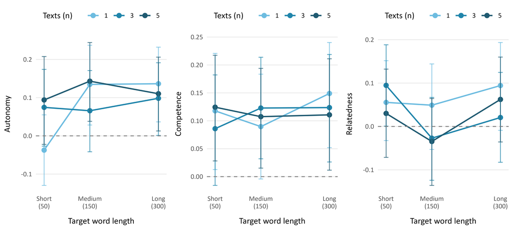

## 4.7 Robustness: Spearman rho

Spearman rho replaces Pearson r throughout. Bootstrap percentile CIs, R = 1000 (reduced because Spearman is slower).

Table 5: Spearman Robustness: LLM–Questionnaire Rho by Condition and Need Dimension. Percentile CIs; R = 1,000.

| Need | Word length | 1 text | 3 texts | 5 texts |
| --- | --- | --- | --- | --- |
| Autonomy | short | -0.05 [-0.15, 0.04] |  |  |
| Autonomy | short |  | 0.06 [-0.03, 0.16] |  |
| Autonomy | short |  |  | 0.06 [-0.04, 0.17] |
| Autonomy | medium | 0.12 [0.02, 0.22] |  |  |
| Autonomy | medium |  | 0.02 [-0.08, 0.12] |  |
| Autonomy | medium |  |  | 0.10 [0.00, 0.20] |
| Autonomy | long | 0.14 [0.04, 0.23] |  |  |
| Autonomy | long |  | 0.08 [-0.01, 0.17] |  |
| Autonomy | long |  |  | 0.11 [0.02, 0.21] |
| Competence | short | 0.10 [0.01, 0.20] |  |  |
| Competence | short |  | 0.05 [-0.05, 0.14] |  |
| Competence | short |  |  | 0.10 [0.01, 0.19] |
| Competence | medium | 0.10 [0.01, 0.19] |  |  |
| Competence | medium |  | 0.14 [0.04, 0.23] |  |
| Competence | medium |  |  | 0.09 [-0.01, 0.19] |
| Competence | long | 0.13 [0.02, 0.22] |  |  |
| Competence | long |  | 0.10 [0.01, 0.20] |  |
| Competence | long |  |  | 0.11 [0.01, 0.21] |
| Relatedness | short | 0.03 [-0.07, 0.13] |  |  |
| Relatedness | short |  | 0.12 [0.02, 0.21] |  |
| Relatedness | short |  |  | -0.00 [-0.10, 0.09] |
| Relatedness | medium | 0.04 [-0.06, 0.13] |  |  |
| Relatedness | medium |  | -0.07 [-0.17, 0.02] |  |
| Relatedness | medium |  |  | -0.07 [-0.17, 0.03] |
| Relatedness | long | 0.11 [0.01, 0.21] |  |  |
| Relatedness | long |  | 0.03 [-0.07, 0.13] |  |
| Relatedness | long |  |  | 0.06 [-0.04, 0.16] |

Note. N = 394. Spearman rho on unrounded continuous scores. Bootstrap percentile CIs, R = 1000. Compare with Pearson r in tbl-rq2b-r.

## 4.8 Robustness: Polychoric r

Polychoric correlation treats both LLM and questionnaire scores as ordinal indicators of latent continuous variables. Scores are rounded to integers before the polychoric estimation. Bootstrap percentile CIs, R = 1000.

Table 6: Polychoric Robustness: LLM–Questionnaire Correlation by Condition and Need Dimension. Percentile CIs; R = 1,000.

| Need | Word length | 1 text | 3 texts | 5 texts |
| --- | --- | --- | --- | --- |
| Autonomy | short | -0.09 [-0.22, 0.05] |  |  |
| Autonomy | short |  | 0.05 [-0.09, 0.22] |  |
| Autonomy | short |  |  | 0.02 [-0.14, 0.16] |
| Autonomy | medium | 0.12 [-0.04, 0.26] |  |  |
| Autonomy | medium |  | 0.08 [-0.06, 0.23] |  |
| Autonomy | medium |  |  | 0.12 [-0.02, 0.24] |
| Autonomy | long | 0.10 [-0.02, 0.27] |  |  |
| Autonomy | long |  | -0.00 [-0.13, 0.14] |  |
| Autonomy | long |  |  | 0.03 [-0.11, 0.16] |
| Competence | short | 0.27 [NA, NA] |  |  |
| Competence | short |  | 0.30 [0.11, 0.48] |  |
| Competence | short |  |  | 0.31 [NA, NA] |
| Competence | medium | 0.10 [-0.12, 0.31] |  |  |
| Competence | medium |  | 0.21 [-0.02, 0.47] |  |
| Competence | medium |  |  | 0.32 [0.10, 0.63] |
| Competence | long | 0.17 [-0.05, 0.44] |  |  |
| Competence | long |  | 0.36 [0.14, 0.58] |  |
| Competence | long |  |  | 0.31 [0.07, 0.54] |
| Relatedness | short | 0.07 [NA, NA] |  |  |
| Relatedness | short |  | 0.07 [NA, NA] |  |
| Relatedness | short |  |  | 0.14 [NA, NA] |
| Relatedness | medium | 0.11 [NA, NA] |  |  |
| Relatedness | medium |  | 0.10 [-0.07, 0.28] |  |
| Relatedness | medium |  |  | 0.02 [NA, NA] |
| Relatedness | long | 0.10 [NA, NA] |  |  |
| Relatedness | long |  | 0.02 [NA, NA] |  |
| Relatedness | long |  |  | 0.08 [NA, NA] |

Note. N = 394. Polychoric r on rounded integer scores. Bootstrap percentile CIs, R = 1000. Compare with Pearson r in tbl-rq2b-r.

## 4.9 Method Comparison Summary

Table 7: Method Comparison: Pearson r, Spearman rho, Polychoric r by Condition and Need Dimension (RQ2b)

| Condition | Need | Pearson r | Spearman rho | Polychoric r |
| --- | --- | --- | --- | --- |
| short-1 | Autonomy | -0.04 | -0.05 | -0.09 |
| short-1 | Competence | 0.12 | 0.10 | 0.27 |
| short-1 | Relatedness | 0.06 | 0.03 | 0.07 |
| short-3 | Autonomy | 0.07 | 0.06 | 0.05 |
| short-3 | Competence | 0.09 | 0.05 | 0.30 |
| short-3 | Relatedness | 0.09 | 0.12 | 0.07 |
| short-5 | Autonomy | 0.09 | 0.06 | 0.02 |
| short-5 | Competence | 0.12 | 0.10 | 0.31 |
| short-5 | Relatedness | 0.03 | 0.00 | 0.14 |
| medium-1 | Autonomy | 0.13 | 0.12 | 0.12 |
| medium-1 | Competence | 0.09 | 0.10 | 0.10 |
| medium-1 | Relatedness | 0.05 | 0.04 | 0.11 |
| medium-3 | Autonomy | 0.07 | 0.02 | 0.08 |
| medium-3 | Competence | 0.12 | 0.14 | 0.21 |
| medium-3 | Relatedness | -0.03 | -0.07 | 0.10 |
| medium-5 | Autonomy | 0.14 | 0.10 | 0.12 |
| medium-5 | Competence | 0.11 | 0.09 | 0.32 |
| medium-5 | Relatedness | -0.03 | -0.07 | 0.02 |
| long-1 | Autonomy | 0.14 | 0.14 | 0.10 |
| long-1 | Competence | 0.15 | 0.13 | 0.17 |
| long-1 | Relatedness | 0.09 | 0.11 | 0.10 |
| long-3 | Autonomy | 0.10 | 0.08 | 0.00 |
| long-3 | Competence | 0.12 | 0.10 | 0.36 |
| long-3 | Relatedness | 0.02 | 0.03 | 0.02 |
| long-5 | Autonomy | 0.11 | 0.11 | 0.03 |
| long-5 | Competence | 0.11 | 0.11 | 0.31 |
| long-5 | Relatedness | 0.06 | 0.06 | 0.08 |

Note. N = 394. Pearson and Spearman: unrounded continuous scores. Polychoric: rounded integer scores.

## 4.10 Full Cross-Correlation Heatmap (6×6)

Each panel shows the full 6×6 lower-triangle Pearson correlation matrix between all LLM-scored and questionnaire need dimensions, per condition. Upper-left block = within-LLM inter-need correlations; lower-right block = within-questionnaire inter-need correlations (condition-invariant, since Q scores are persona-level constants). The two off-diagonal blocks are the LLM×Q cross-correlations: the main diagonal of those blocks (LLM Aut×Q Aut, LLM Com×Q Com, LLM Rel×Q Rel) reflects convergent validity; off-diagonal cells reflect discriminant validity.

Figure 6: 6×6 cross-correlation matrix (LLM scores × questionnaire scores) per experimental condition (RQ2b). Upper-left block: within-LLM inter-need correlations. Lower-right block: within-questionnaire inter-need correlations (condition-invariant). Off-diagonal blocks: LLM × questionnaire cross-correlations; main diagonal of those blocks = convergent validity; off-diagonal = discriminant. Grey diagonal = 1.0 (suppressed). Rows = target word length; columns = number of texts.

[figure not shown]

# 5 H1c — Discriminant Validity (AI Surrogates, All 9 Conditions)

H1c requires that each LLM dimension correlates more strongly with its matching questionnaire dimension (convergent, r_within) than with non-matching dimensions (discriminant, r_cross). Tested via Steiger’s (1980) dependent overlapping groups test (`cocor::cocor.dep.groups.overlap`). Six comparisons per condition × 9 conditions = 54 tests. All two-tailed.

## 5.1 Steiger Tests

```
h1c_ai_results saved (54 rows).
```

Table 8: H1c: Discriminant Validity — Steiger’s Test per Condition (AI Surrogates, N = 54 Tests)

| condition | llm_dim | comparison | r_within | r_cross | diff | ci_lo | ci_hi | steiger_z | p_value | n |
| --- | --- | --- | --- | --- | --- | --- | --- | --- | --- | --- |
| 1 text × 50w | llm_aut_mean | Q_Aut vs Q_Com | -0.04 | 0.007 | -0.044 | -0.19 | 0.10 | -0.59 | 0.552 | 394 |
| 1 text × 50w | llm_aut_mean | Q_Aut vs Q_Rel | -0.04 | 0.051 | -0.088 | -0.21 | 0.04 | -1.40 | 0.160 | 394 |
| 1 text × 50w | llm_com_mean | Q_Com vs Q_Aut | 0.12 | 0.105 | 0.013 | -0.13 | 0.16 | 0.18 | 0.859 | 394 |
| 1 text × 50w | llm_com_mean | Q_Com vs Q_Rel | 0.12 | 0.031 | 0.087 | -0.06 | 0.23 | 1.18 | 0.237 | 394 |
| 1 text × 50w | llm_rel_mean | Q_Rel vs Q_Aut | 0.06 | 0.013 | 0.043 | -0.08 | 0.16 | 0.68 | 0.499 | 394 |
| 1 text × 50w | llm_rel_mean | Q_Rel vs Q_Com | 0.06 | 0.021 | 0.034 | -0.11 | 0.18 | 0.47 | 0.639 | 394 |
| 1 text × 150w | llm_aut_mean | Q_Aut vs Q_Com | 0.13 | 0.041 | 0.094 | -0.05 | 0.24 | 1.28 | 0.201 | 394 |
| 1 text × 150w | llm_aut_mean | Q_Aut vs Q_Rel | 0.13 | 0.035 | 0.100 | -0.02 | 0.22 | 1.59 | 0.111 | 394 |
| 1 text × 150w | llm_com_mean | Q_Com vs Q_Aut | 0.09 | 0.134 | -0.044 | -0.19 | 0.10 | -0.60 | 0.547 | 394 |
| 1 text × 150w | llm_com_mean | Q_Com vs Q_Rel | 0.09 | 0.081 | 0.009 | -0.13 | 0.15 | 0.12 | 0.904 | 394 |
| 1 text × 150w | llm_rel_mean | Q_Rel vs Q_Aut | 0.05 | -0.018 | 0.067 | -0.06 | 0.19 | 1.06 | 0.291 | 394 |
| 1 text × 150w | llm_rel_mean | Q_Rel vs Q_Com | 0.05 | -0.067 | 0.117 | -0.03 | 0.26 | 1.59 | 0.113 | 394 |
| 1 text × 300w | llm_aut_mean | Q_Aut vs Q_Com | 0.14 | 0.098 | 0.038 | -0.11 | 0.18 | 0.52 | 0.602 | 394 |
| 1 text × 300w | llm_aut_mean | Q_Aut vs Q_Rel | 0.14 | 0.086 | 0.051 | -0.07 | 0.17 | 0.81 | 0.418 | 394 |
| 1 text × 300w | llm_com_mean | Q_Com vs Q_Aut | 0.15 | 0.219 | -0.070 | -0.22 | 0.07 | -0.96 | 0.335 | 394 |
| 1 text × 300w | llm_com_mean | Q_Com vs Q_Rel | 0.15 | 0.032 | 0.117 | -0.03 | 0.26 | 1.60 | 0.109 | 394 |
| 1 text × 300w | llm_rel_mean | Q_Rel vs Q_Aut | 0.09 | -0.042 | 0.137 | 0.01 | 0.25 | 2.17 | 0.030 | 394 |
| 1 text × 300w | llm_rel_mean | Q_Rel vs Q_Com | 0.09 | -0.085 | 0.179 | 0.04 | 0.31 | 2.44 | 0.015 | 394 |
| 3 texts × 50w | llm_aut_mean | Q_Aut vs Q_Com | 0.07 | 0.017 | 0.058 | -0.09 | 0.20 | 0.78 | 0.434 | 394 |
| 3 texts × 50w | llm_aut_mean | Q_Aut vs Q_Rel | 0.07 | 0.002 | 0.073 | -0.05 | 0.19 | 1.16 | 0.247 | 394 |
| 3 texts × 50w | llm_com_mean | Q_Com vs Q_Aut | 0.09 | 0.081 | 0.005 | -0.14 | 0.15 | 0.07 | 0.945 | 394 |
| 3 texts × 50w | llm_com_mean | Q_Com vs Q_Rel | 0.09 | -0.031 | 0.117 | -0.03 | 0.26 | 1.60 | 0.111 | 394 |
| 3 texts × 50w | llm_rel_mean | Q_Rel vs Q_Aut | 0.09 | -0.013 | 0.107 | -0.02 | 0.23 | 1.71 | 0.088 | 394 |
| 3 texts × 50w | llm_rel_mean | Q_Rel vs Q_Com | 0.09 | -0.004 | 0.099 | -0.05 | 0.24 | 1.35 | 0.178 | 394 |
| 3 texts × 150w | llm_aut_mean | Q_Aut vs Q_Com | 0.07 | 0.062 | 0.003 | -0.14 | 0.15 | 0.04 | 0.964 | 394 |
| 3 texts × 150w | llm_aut_mean | Q_Aut vs Q_Rel | 0.07 | 0.124 | -0.058 | -0.18 | 0.06 | -0.93 | 0.351 | 394 |
| 3 texts × 150w | llm_com_mean | Q_Com vs Q_Aut | 0.12 | 0.120 | 0.003 | -0.14 | 0.15 | 0.04 | 0.970 | 394 |
| 3 texts × 150w | llm_com_mean | Q_Com vs Q_Rel | 0.12 | 0.070 | 0.053 | -0.09 | 0.20 | 0.72 | 0.472 | 394 |
| 3 texts × 150w | llm_rel_mean | Q_Rel vs Q_Aut | -0.03 | -0.108 | 0.081 | -0.04 | 0.20 | 1.28 | 0.199 | 394 |
| 3 texts × 150w | llm_rel_mean | Q_Rel vs Q_Com | -0.03 | -0.045 | 0.018 | -0.13 | 0.16 | 0.24 | 0.808 | 394 |
| 3 texts × 300w | llm_aut_mean | Q_Aut vs Q_Com | 0.10 | 0.002 | 0.096 | -0.05 | 0.24 | 1.30 | 0.195 | 394 |
| 3 texts × 300w | llm_aut_mean | Q_Aut vs Q_Rel | 0.10 | 0.049 | 0.050 | -0.07 | 0.17 | 0.79 | 0.428 | 394 |
| 3 texts × 300w | llm_com_mean | Q_Com vs Q_Aut | 0.12 | 0.133 | -0.009 | -0.15 | 0.14 | -0.13 | 0.900 | 394 |
| 3 texts × 300w | llm_com_mean | Q_Com vs Q_Rel | 0.12 | -0.002 | 0.126 | -0.02 | 0.26 | 1.72 | 0.085 | 394 |
| 3 texts × 300w | llm_rel_mean | Q_Rel vs Q_Aut | 0.02 | -0.022 | 0.042 | -0.08 | 0.16 | 0.67 | 0.503 | 394 |
| 3 texts × 300w | llm_rel_mean | Q_Rel vs Q_Com | 0.02 | -0.041 | 0.061 | -0.08 | 0.20 | 0.84 | 0.403 | 394 |
| 5 texts × 50w | llm_aut_mean | Q_Aut vs Q_Com | 0.09 | 0.098 | -0.004 | -0.15 | 0.14 | -0.06 | 0.954 | 394 |
| 5 texts × 50w | llm_aut_mean | Q_Aut vs Q_Rel | 0.09 | 0.122 | -0.028 | -0.15 | 0.10 | -0.45 | 0.651 | 394 |
| 5 texts × 50w | llm_com_mean | Q_Com vs Q_Aut | 0.12 | 0.126 | -0.001 | -0.15 | 0.14 | -0.02 | 0.988 | 394 |
| 5 texts × 50w | llm_com_mean | Q_Com vs Q_Rel | 0.12 | 0.077 | 0.047 | -0.10 | 0.19 | 0.64 | 0.519 | 394 |
| 5 texts × 50w | llm_rel_mean | Q_Rel vs Q_Aut | 0.03 | -0.027 | 0.057 | -0.07 | 0.18 | 0.90 | 0.366 | 394 |
| 5 texts × 50w | llm_rel_mean | Q_Rel vs Q_Com | 0.03 | -0.017 | 0.047 | -0.10 | 0.19 | 0.64 | 0.520 | 394 |
| 5 texts × 150w | llm_aut_mean | Q_Aut vs Q_Com | 0.14 | 0.065 | 0.078 | -0.07 | 0.22 | 1.06 | 0.289 | 394 |
| 5 texts × 150w | llm_aut_mean | Q_Aut vs Q_Rel | 0.14 | 0.145 | -0.001 | -0.13 | 0.12 | -0.02 | 0.981 | 394 |
| 5 texts × 150w | llm_com_mean | Q_Com vs Q_Aut | 0.11 | 0.128 | -0.021 | -0.17 | 0.12 | -0.29 | 0.776 | 394 |
| 5 texts × 150w | llm_com_mean | Q_Com vs Q_Rel | 0.11 | 0.094 | 0.013 | -0.13 | 0.16 | 0.18 | 0.856 | 394 |
| 5 texts × 150w | llm_rel_mean | Q_Rel vs Q_Aut | -0.03 | -0.019 | -0.015 | -0.14 | 0.11 | -0.24 | 0.809 | 394 |
| 5 texts × 150w | llm_rel_mean | Q_Rel vs Q_Com | -0.03 | -0.094 | 0.059 | -0.08 | 0.20 | 0.80 | 0.421 | 394 |
| 5 texts × 300w | llm_aut_mean | Q_Aut vs Q_Com | 0.11 | 0.041 | 0.070 | -0.08 | 0.21 | 0.94 | 0.346 | 394 |
| 5 texts × 300w | llm_aut_mean | Q_Aut vs Q_Rel | 0.11 | 0.081 | 0.029 | -0.09 | 0.15 | 0.47 | 0.642 | 394 |
| 5 texts × 300w | llm_com_mean | Q_Com vs Q_Aut | 0.11 | 0.110 | 0.000 | -0.14 | 0.14 | 0.00 | 0.997 | 394 |
| 5 texts × 300w | llm_com_mean | Q_Com vs Q_Rel | 0.11 | 0.088 | 0.022 | -0.12 | 0.17 | 0.31 | 0.760 | 394 |
| 5 texts × 300w | llm_rel_mean | Q_Rel vs Q_Aut | 0.06 | -0.053 | 0.115 | -0.01 | 0.23 | 1.82 | 0.068 | 394 |
| 5 texts × 300w | llm_rel_mean | Q_Rel vs Q_Com | 0.06 | -0.028 | 0.090 | -0.05 | 0.23 | 1.23 | 0.219 | 394 |

Note. Steiger (1980) test for dependent overlapping correlations (cocor::cocor.dep.groups.overlap). Two-tailed. r_within = LLM-matching Q correlation; r_cross = LLM-nonmatching Q correlation. CI = 95% Fisher-z CI on r_within - r_cross.

## 5.2 H1c Heatmap

Figure 7: H1c: LLM × Questionnaire Correlation Matrix per Condition (AI Surrogates). Bold border = convergent validity (same need, different method); no border = discriminant. Rows = target word length; columns = number of texts. Red = negative r, white = 0, blue = positive r.

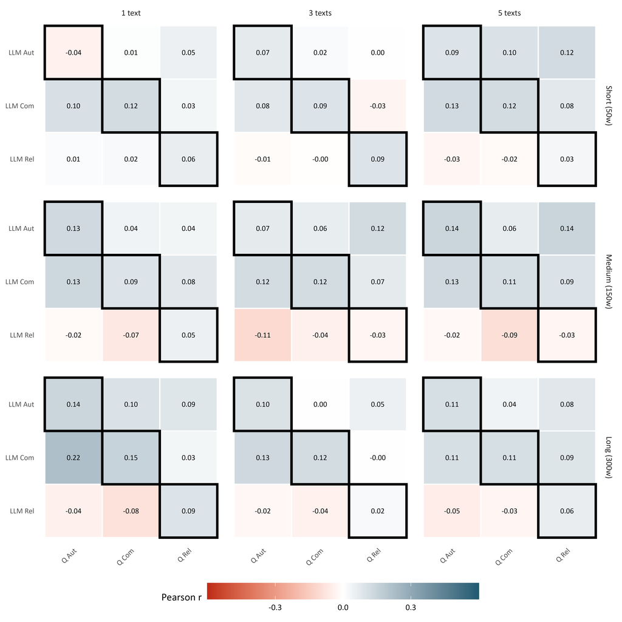

## 5.3 H1c MTMM Dot Plot

Figure 8: H1c: MTMM Validity Coefficient Comparison — Campbell-Fiske Criterion (AI Surrogates). Filled circle = convergent r (same need); open circles = discriminant r (non-matching Q dimensions). Discriminant validity holds when the filled circle lies to the right of all open circles in a row.

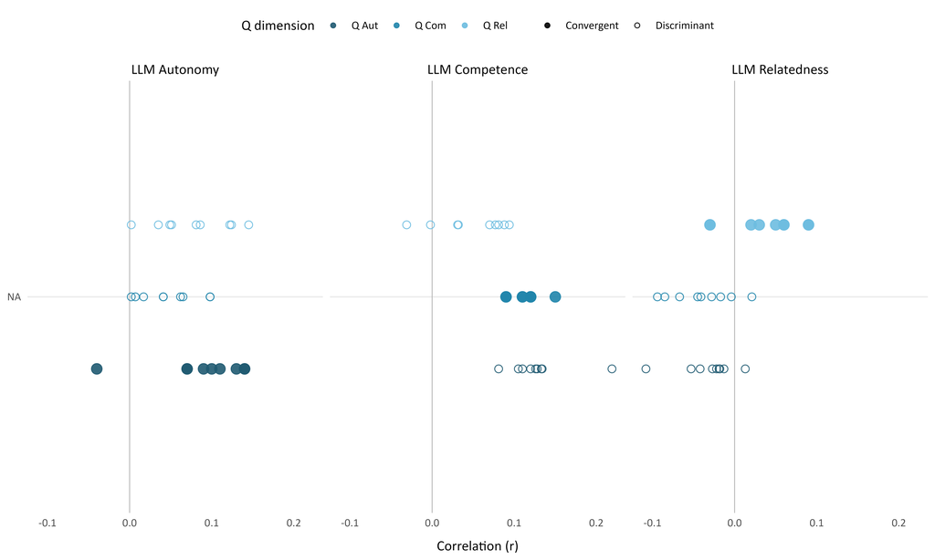

## 5.4 H1c Spearman Robustness

Table 9: H1c Spearman Robustness: Steiger’s Test with Spearman rho (AI Surrogates, N = 54 Tests; Approximation)

| condition | llm_dim | comparison | rho_within | rho_cross | diff | ci_lo | ci_hi | steiger_z | p_value | n |
| --- | --- | --- | --- | --- | --- | --- | --- | --- | --- | --- |
| 1 text × 50w | llm_aut_mean | Q_Aut vs Q_Com | -0.05 | -0.004 | -0.050 | -0.19 | 0.10 | -0.66 | 0.506 | 394 |
| 1 text × 50w | llm_aut_mean | Q_Aut vs Q_Rel | -0.05 | 0.024 | -0.078 | -0.21 | 0.05 | -1.16 | 0.245 | 394 |
| 1 text × 50w | llm_com_mean | Q_Com vs Q_Aut | 0.10 | 0.114 | -0.011 | -0.16 | 0.14 | -0.15 | 0.879 | 394 |
| 1 text × 50w | llm_com_mean | Q_Com vs Q_Rel | 0.10 | -0.016 | 0.119 | -0.03 | 0.26 | 1.61 | 0.108 | 394 |
| 1 text × 50w | llm_rel_mean | Q_Rel vs Q_Aut | 0.03 | -0.016 | 0.050 | -0.08 | 0.18 | 0.74 | 0.457 | 394 |
| 1 text × 50w | llm_rel_mean | Q_Rel vs Q_Com | 0.03 | 0.033 | 0.001 | -0.14 | 0.14 | 0.01 | 0.991 | 394 |
| 1 text × 150w | llm_aut_mean | Q_Aut vs Q_Com | 0.12 | 0.055 | 0.068 | -0.08 | 0.21 | 0.91 | 0.363 | 394 |
| 1 text × 150w | llm_aut_mean | Q_Aut vs Q_Rel | 0.12 | -0.015 | 0.138 | 0.01 | 0.26 | 2.07 | 0.038 | 394 |
| 1 text × 150w | llm_com_mean | Q_Com vs Q_Aut | 0.10 | 0.126 | -0.028 | -0.17 | 0.12 | -0.38 | 0.704 | 394 |
| 1 text × 150w | llm_com_mean | Q_Com vs Q_Rel | 0.10 | 0.044 | 0.054 | -0.09 | 0.20 | 0.73 | 0.465 | 394 |
| 1 text × 150w | llm_rel_mean | Q_Rel vs Q_Aut | 0.04 | -0.034 | 0.071 | -0.06 | 0.20 | 1.06 | 0.290 | 394 |
| 1 text × 150w | llm_rel_mean | Q_Rel vs Q_Com | 0.04 | -0.069 | 0.106 | -0.04 | 0.25 | 1.43 | 0.152 | 394 |
| 1 text × 300w | llm_aut_mean | Q_Aut vs Q_Com | 0.14 | 0.085 | 0.052 | -0.09 | 0.20 | 0.71 | 0.481 | 394 |
| 1 text × 300w | llm_aut_mean | Q_Aut vs Q_Rel | 0.14 | 0.117 | 0.020 | -0.11 | 0.15 | 0.31 | 0.756 | 394 |
| 1 text × 300w | llm_com_mean | Q_Com vs Q_Aut | 0.13 | 0.201 | -0.076 | -0.22 | 0.07 | -1.04 | 0.300 | 394 |
| 1 text × 300w | llm_com_mean | Q_Com vs Q_Rel | 0.13 | 0.007 | 0.118 | -0.03 | 0.26 | 1.60 | 0.109 | 394 |
| 1 text × 300w | llm_rel_mean | Q_Rel vs Q_Aut | 0.11 | -0.036 | 0.145 | 0.01 | 0.27 | 2.18 | 0.029 | 394 |
| 1 text × 300w | llm_rel_mean | Q_Rel vs Q_Com | 0.11 | -0.077 | 0.187 | 0.04 | 0.32 | 2.53 | 0.011 | 394 |
| 3 texts × 50w | llm_aut_mean | Q_Aut vs Q_Com | 0.06 | 0.011 | 0.050 | -0.10 | 0.19 | 0.67 | 0.506 | 394 |
| 3 texts × 50w | llm_aut_mean | Q_Aut vs Q_Rel | 0.06 | -0.001 | 0.061 | -0.07 | 0.19 | 0.91 | 0.360 | 394 |
| 3 texts × 50w | llm_com_mean | Q_Com vs Q_Aut | 0.05 | 0.071 | -0.020 | -0.17 | 0.13 | -0.27 | 0.787 | 394 |
| 3 texts × 50w | llm_com_mean | Q_Com vs Q_Rel | 0.05 | -0.062 | 0.113 | -0.03 | 0.25 | 1.52 | 0.128 | 394 |
| 3 texts × 50w | llm_rel_mean | Q_Rel vs Q_Aut | 0.12 | -0.023 | 0.141 | 0.01 | 0.27 | 2.11 | 0.034 | 394 |
| 3 texts × 50w | llm_rel_mean | Q_Rel vs Q_Com | 0.12 | -0.025 | 0.142 | 0.00 | 0.28 | 1.93 | 0.053 | 394 |
| 3 texts × 150w | llm_aut_mean | Q_Aut vs Q_Com | 0.02 | 0.068 | -0.051 | -0.20 | 0.10 | -0.68 | 0.497 | 394 |
| 3 texts × 150w | llm_aut_mean | Q_Aut vs Q_Rel | 0.02 | 0.106 | -0.089 | -0.22 | 0.04 | -1.34 | 0.180 | 394 |
| 3 texts × 150w | llm_com_mean | Q_Com vs Q_Aut | 0.14 | 0.115 | 0.022 | -0.12 | 0.17 | 0.29 | 0.770 | 394 |
| 3 texts × 150w | llm_com_mean | Q_Com vs Q_Rel | 0.14 | 0.025 | 0.112 | -0.03 | 0.25 | 1.53 | 0.126 | 394 |
| 3 texts × 150w | llm_rel_mean | Q_Rel vs Q_Aut | -0.07 | -0.117 | 0.047 | -0.08 | 0.18 | 0.72 | 0.474 | 394 |
| 3 texts × 150w | llm_rel_mean | Q_Rel vs Q_Com | -0.07 | -0.035 | -0.035 | -0.18 | 0.11 | -0.47 | 0.638 | 394 |
| 3 texts × 300w | llm_aut_mean | Q_Aut vs Q_Com | 0.08 | -0.024 | 0.102 | -0.05 | 0.24 | 1.36 | 0.174 | 394 |
| 3 texts × 300w | llm_aut_mean | Q_Aut vs Q_Rel | 0.08 | 0.064 | 0.014 | -0.12 | 0.14 | 0.21 | 0.832 | 394 |
| 3 texts × 300w | llm_com_mean | Q_Com vs Q_Aut | 0.10 | 0.144 | -0.040 | -0.19 | 0.11 | -0.54 | 0.592 | 394 |
| 3 texts × 300w | llm_com_mean | Q_Com vs Q_Rel | 0.10 | -0.010 | 0.115 | -0.03 | 0.25 | 1.56 | 0.120 | 394 |
| 3 texts × 300w | llm_rel_mean | Q_Rel vs Q_Aut | 0.03 | -0.020 | 0.052 | -0.08 | 0.18 | 0.77 | 0.440 | 394 |
| 3 texts × 300w | llm_rel_mean | Q_Rel vs Q_Com | 0.03 | -0.041 | 0.073 | -0.07 | 0.21 | 0.99 | 0.324 | 394 |
| 5 texts × 50w | llm_aut_mean | Q_Aut vs Q_Com | 0.06 | 0.073 | -0.009 | -0.15 | 0.14 | -0.11 | 0.909 | 394 |
| 5 texts × 50w | llm_aut_mean | Q_Aut vs Q_Rel | 0.06 | 0.123 | -0.059 | -0.19 | 0.07 | -0.89 | 0.376 | 394 |
| 5 texts × 50w | llm_com_mean | Q_Com vs Q_Aut | 0.10 | 0.115 | -0.015 | -0.16 | 0.13 | -0.20 | 0.841 | 394 |
| 5 texts × 50w | llm_com_mean | Q_Com vs Q_Rel | 0.10 | 0.025 | 0.076 | -0.07 | 0.22 | 1.03 | 0.304 | 394 |
| 5 texts × 50w | llm_rel_mean | Q_Rel vs Q_Aut | 0.00 | -0.039 | 0.035 | -0.10 | 0.16 | 0.53 | 0.599 | 394 |
| 5 texts × 50w | llm_rel_mean | Q_Rel vs Q_Com | 0.00 | -0.020 | 0.016 | -0.13 | 0.16 | 0.22 | 0.830 | 394 |
| 5 texts × 150w | llm_aut_mean | Q_Aut vs Q_Com | 0.10 | 0.045 | 0.057 | -0.09 | 0.20 | 0.77 | 0.444 | 394 |
| 5 texts × 150w | llm_aut_mean | Q_Aut vs Q_Rel | 0.10 | 0.096 | 0.006 | -0.12 | 0.14 | 0.09 | 0.928 | 394 |
| 5 texts × 150w | llm_com_mean | Q_Com vs Q_Aut | 0.09 | 0.148 | -0.059 | -0.20 | 0.09 | -0.80 | 0.424 | 394 |
| 5 texts × 150w | llm_com_mean | Q_Com vs Q_Rel | 0.09 | 0.047 | 0.042 | -0.10 | 0.18 | 0.57 | 0.572 | 394 |
| 5 texts × 150w | llm_rel_mean | Q_Rel vs Q_Aut | -0.07 | -0.033 | -0.034 | -0.16 | 0.10 | -0.51 | 0.608 | 394 |
| 5 texts × 150w | llm_rel_mean | Q_Rel vs Q_Com | -0.07 | -0.103 | 0.036 | -0.11 | 0.18 | 0.49 | 0.621 | 394 |
| 5 texts × 300w | llm_aut_mean | Q_Aut vs Q_Com | 0.11 | 0.025 | 0.088 | -0.06 | 0.23 | 1.18 | 0.239 | 394 |
| 5 texts × 300w | llm_aut_mean | Q_Aut vs Q_Rel | 0.11 | 0.068 | 0.045 | -0.09 | 0.17 | 0.68 | 0.497 | 394 |
| 5 texts × 300w | llm_com_mean | Q_Com vs Q_Aut | 0.11 | 0.094 | 0.020 | -0.13 | 0.17 | 0.27 | 0.785 | 394 |
| 5 texts × 300w | llm_com_mean | Q_Com vs Q_Rel | 0.11 | 0.033 | 0.081 | -0.06 | 0.22 | 1.11 | 0.269 | 394 |
| 5 texts × 300w | llm_rel_mean | Q_Rel vs Q_Aut | 0.06 | -0.066 | 0.125 | -0.01 | 0.25 | 1.88 | 0.060 | 394 |
| 5 texts × 300w | llm_rel_mean | Q_Rel vs Q_Com | 0.06 | -0.030 | 0.090 | -0.06 | 0.23 | 1.21 | 0.225 | 394 |

Note. Steiger (1980) applied to Spearman rho — approximation; compare with Pearson results in tbl-h1c-ai.

# 6 H1d — Structural Consistency (AI Surrogates, All 9 Conditions)

H1d asks whether the inter-need correlation pattern in LLM scores mirrors the pattern in questionnaire scores. Meta-r = Pearson r between the two 3-element inter-need vectors (Aut–Com, Aut–Rel, Com–Rel). N = 3 pairs per condition — descriptive only; no inferential test applied.

Questionnaire inter-need correlations are constant across conditions (Q scores do not vary by condition); condition-to-condition variation in meta-r reflects shifts in the LLM’s inter-need structure.

## 6.1 Meta-r Table

Table 10: H1d: Structural Consistency — Inter-Need Correlations and Meta-r per Condition (AI Surrogates; N = 3 pairs, descriptive only)

| condition | pair | r_Q | r_LLM | meta_r |
| --- | --- | --- | --- | --- |
| 1 text × 50w | Aut-Com | -0.074 | 0.41 | -0.61 |
| 1 text × 50w | Aut-Rel | 0.223 | 0.02 |  |
| 1 text × 50w | Com-Rel | -0.058 | 0.06 |  |
| 1 text × 150w | Aut-Com | -0.074 | 0.42 | -0.41 |
| 1 text × 150w | Aut-Rel | 0.223 | -0.03 |  |
| 1 text × 150w | Com-Rel | -0.058 | -0.11 |  |
| 1 text × 300w | Aut-Com | -0.074 | 0.42 | -0.33 |
| 1 text × 300w | Aut-Rel | 0.223 | 0.00 |  |
| 1 text × 300w | Com-Rel | -0.058 | -0.14 |  |
| 3 texts × 50w | Aut-Com | -0.074 | 0.43 | -0.45 |
| 3 texts × 50w | Aut-Rel | 0.223 | 0.08 |  |
| 3 texts × 50w | Com-Rel | -0.058 | 0.03 |  |
| 3 texts × 150w | Aut-Com | -0.074 | 0.36 | -0.36 |
| 3 texts × 150w | Aut-Rel | 0.223 | -0.02 |  |
| 3 texts × 150w | Com-Rel | -0.058 | -0.12 |  |
| 3 texts × 300w | Aut-Com | -0.074 | 0.40 | -0.47 |
| 3 texts × 300w | Aut-Rel | 0.223 | -0.05 |  |
| 3 texts × 300w | Com-Rel | -0.058 | -0.09 |  |
| 5 texts × 50w | Aut-Com | -0.074 | 0.37 | -0.12 |
| 5 texts × 50w | Aut-Rel | 0.223 | 0.08 |  |
| 5 texts × 50w | Com-Rel | -0.058 | -0.14 |  |
| 5 texts × 150w | Aut-Com | -0.074 | 0.43 | -0.19 |
| 5 texts × 150w | Aut-Rel | 0.223 | 0.07 |  |
| 5 texts × 150w | Com-Rel | -0.058 | -0.14 |  |
| 5 texts × 300w | Aut-Com | -0.074 | 0.45 | -0.64 |
| 5 texts × 300w | Aut-Rel | 0.223 | -0.09 |  |
| 5 texts × 300w | Com-Rel | -0.058 | -0.02 |  |

Note. meta_r = Pearson r between the three Q inter-need correlations and three LLM inter-need correlations per condition (condition-level statistic, shown once). N = 3 pairs; no inferential test. Q inter-need correlations are constant across conditions.

## 6.2 H1d Forest Plot

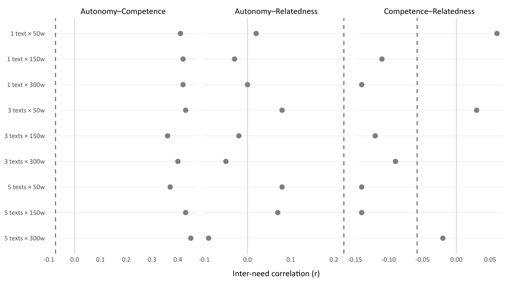

## 6.3 H1d Spearman Robustness

Table 11: H1d Spearman Robustness: Inter-Need Rho and Meta-r per Condition (AI Surrogates; N = 3 pairs, descriptive only)

| condition | pair | rho_Q | rho_LLM | meta_r |
| --- | --- | --- | --- | --- |
| 1 text × 50w | Aut-Com | -0.101 | 0.41 | -0.66 |
| 1 text × 50w | Aut-Rel | 0.130 | 0.06 |  |
| 1 text × 50w | Com-Rel | -0.070 | 0.09 |  |
| 1 text × 150w | Aut-Com | -0.101 | 0.44 | -0.49 |
| 1 text × 150w | Aut-Rel | 0.130 | -0.03 |  |
| 1 text × 150w | Com-Rel | -0.070 | -0.11 |  |
| 1 text × 300w | Aut-Com | -0.101 | 0.43 | -0.40 |
| 1 text × 300w | Aut-Rel | 0.130 | 0.00 |  |
| 1 text × 300w | Com-Rel | -0.070 | -0.14 |  |
| 3 texts × 50w | Aut-Com | -0.101 | 0.45 | -0.47 |
| 3 texts × 50w | Aut-Rel | 0.130 | 0.08 |  |
| 3 texts × 50w | Com-Rel | -0.070 | 0.00 |  |
| 3 texts × 150w | Aut-Com | -0.101 | 0.39 | -0.47 |
| 3 texts × 150w | Aut-Rel | 0.130 | -0.02 |  |
| 3 texts × 150w | Com-Rel | -0.070 | -0.10 |  |
| 3 texts × 300w | Aut-Com | -0.101 | 0.40 | -0.49 |
| 3 texts × 300w | Aut-Rel | 0.130 | -0.03 |  |
| 3 texts × 300w | Com-Rel | -0.070 | -0.10 |  |
| 5 texts × 50w | Aut-Com | -0.101 | 0.38 | -0.23 |
| 5 texts × 50w | Aut-Rel | 0.130 | 0.06 |  |
| 5 texts × 50w | Com-Rel | -0.070 | -0.16 |  |
| 5 texts × 150w | Aut-Com | -0.101 | 0.45 | -0.33 |
| 5 texts × 150w | Aut-Rel | 0.130 | 0.04 |  |
| 5 texts × 150w | Com-Rel | -0.070 | -0.15 |  |
| 5 texts × 300w | Aut-Com | -0.101 | 0.43 | -0.70 |
| 5 texts × 300w | Aut-Rel | 0.130 | -0.11 |  |
| 5 texts × 300w | Com-Rel | -0.070 | -0.03 |  |

Note. Spearman rho substituted throughout. meta-r remains Pearson on the 3-element rho vectors; shown once per condition.

# 7 Appendix: BCa Sensitivity Tables

Table 12: Appendix: BCa vs Percentile CIs for SD — All 27 Condition × Need Cells

| need | condition | perc_lo | perc_hi | bca_lo | bca_hi | max_diff |
| --- | --- | --- | --- | --- | --- | --- |
| Autonomy | short-1 | 0.439 | 0.500 | 0.443 | 0.505 | 0.005 |
| Autonomy | short-3 | 0.353 | 0.441 | 0.357 | 0.445 | 0.005 |
| Autonomy | short-5 | 0.362 | 0.444 | 0.366 | 0.447 | 0.004 |
| Autonomy | medium-1 | 0.354 | 0.426 | 0.358 | 0.429 | 0.004 |
| Autonomy | medium-3 | 0.397 | 0.465 | 0.400 | 0.467 | 0.003 |
| Autonomy | medium-5 | 0.405 | 0.490 | 0.411 | 0.496 | 0.006 |
| Autonomy | long-1 | 0.406 | 0.460 | 0.409 | 0.463 | 0.004 |
| Autonomy | long-3 | 0.432 | 0.484 | 0.435 | 0.486 | 0.003 |
| Autonomy | long-5 | 0.433 | 0.492 | 0.437 | 0.496 | 0.004 |
| Competence | short-1 | 0.406 | 0.451 | 0.407 | 0.452 | 0.001 |
| Competence | short-3 | 0.454 | 0.483 | 0.456 | 0.485 | 0.002 |
| Competence | short-5 | 0.452 | 0.481 | 0.455 | 0.486 | 0.005 |
| Competence | medium-1 | 0.422 | 0.463 | 0.424 | 0.464 | 0.002 |
| Competence | medium-3 | 0.339 | 0.402 | 0.341 | 0.404 | 0.002 |
| Competence | medium-5 | 0.311 | 0.380 | 0.314 | 0.382 | 0.003 |
| Competence | long-1 | 0.330 | 0.411 | 0.334 | 0.414 | 0.004 |
| Competence | long-3 | 0.317 | 0.399 | 0.319 | 0.401 | 0.003 |
| Competence | long-5 | 0.284 | 0.369 | 0.288 | 0.373 | 0.004 |
| Relatedness | short-1 | 0.234 | 0.321 | 0.239 | 0.327 | 0.006 |
| Relatedness | short-3 | 0.358 | 0.442 | 0.360 | 0.445 | 0.003 |
| Relatedness | short-5 | 0.379 | 0.444 | 0.381 | 0.446 | 0.002 |
| Relatedness | medium-1 | 0.373 | 0.424 | 0.374 | 0.425 | 0.001 |
| Relatedness | medium-3 | 0.427 | 0.469 | 0.429 | 0.472 | 0.003 |
| Relatedness | medium-5 | 0.450 | 0.473 | 0.451 | 0.474 | 0.001 |
| Relatedness | long-1 | 0.451 | 0.473 | 0.452 | 0.473 | 0.001 |
| Relatedness | long-3 | 0.450 | 0.470 | 0.450 | 0.471 | 0.001 |
| Relatedness | long-5 | 0.451 | 0.471 | 0.451 | 0.471 | 0.001 |

Note. Divergence threshold = 0.02. Cells with max_diff > 0.02 also reported in check_bca_divergence_sd.

Table 13: Appendix: BCa vs Percentile CIs for Pearson r — All 27 Condition × Need Cells

| need | condition | perc_lo | perc_hi | bca_lo | bca_hi | max_diff |
| --- | --- | --- | --- | --- | --- | --- |
| Autonomy | short-1 | -0.130 | 0.055 | -0.129 | 0.055 | 0.000 |
| Autonomy | short-3 | -0.027 | 0.174 | -0.028 | 0.173 | 0.001 |
| Autonomy | short-5 | -0.022 | 0.208 | -0.020 | 0.209 | 0.002 |
| Autonomy | medium-1 | 0.028 | 0.237 | 0.029 | 0.238 | 0.001 |
| Autonomy | medium-3 | -0.042 | 0.171 | -0.039 | 0.174 | 0.003 |
| Autonomy | medium-5 | 0.038 | 0.244 | 0.039 | 0.246 | 0.001 |
| Autonomy | long-1 | 0.037 | 0.232 | 0.036 | 0.232 | 0.000 |
| Autonomy | long-3 | 0.001 | 0.191 | 0.002 | 0.192 | 0.001 |
| Autonomy | long-5 | 0.013 | 0.206 | 0.014 | 0.207 | 0.001 |
| Competence | short-1 | 0.012 | 0.221 | 0.013 | 0.221 | 0.001 |
| Competence | short-3 | -0.016 | 0.182 | -0.015 | 0.183 | 0.001 |
| Competence | short-5 | 0.028 | 0.218 | 0.028 | 0.216 | 0.002 |
| Competence | medium-1 | -0.004 | 0.184 | -0.007 | 0.181 | 0.003 |
| Competence | medium-3 | 0.032 | 0.214 | 0.032 | 0.214 | 0.000 |
| Competence | medium-5 | 0.015 | 0.194 | 0.015 | 0.195 | 0.000 |
| Competence | long-1 | 0.052 | 0.240 | 0.054 | 0.242 | 0.002 |
| Competence | long-3 | 0.026 | 0.219 | 0.027 | 0.221 | 0.002 |
| Competence | long-5 | 0.012 | 0.211 | 0.013 | 0.212 | 0.001 |
| Relatedness | short-1 | -0.033 | 0.152 | -0.024 | 0.163 | 0.011 |
| Relatedness | short-3 | 0.001 | 0.188 | 0.002 | 0.191 | 0.002 |
| Relatedness | short-5 | -0.071 | 0.132 | -0.072 | 0.132 | 0.001 |
| Relatedness | medium-1 | -0.053 | 0.145 | -0.053 | 0.144 | 0.000 |
| Relatedness | medium-3 | -0.124 | 0.067 | -0.123 | 0.068 | 0.001 |
| Relatedness | medium-5 | -0.136 | 0.064 | -0.133 | 0.068 | 0.004 |
| Relatedness | long-1 | -0.009 | 0.194 | -0.011 | 0.192 | 0.002 |
| Relatedness | long-3 | -0.083 | 0.125 | -0.084 | 0.123 | 0.002 |
| Relatedness | long-5 | -0.036 | 0.160 | -0.036 | 0.160 | 0.000 |

Note. Divergence threshold = 0.02. Cells with max_diff > 0.02 also reported in check_bca_divergence_r.

# 8 Session Info